# Biostatistics for Biomarkers and Longitudinal Outcomes in A4/LEARN

A workshop in R using A4LEARN

Michael Donohue, PhD

# Workshop overview

## Goals for today

- Strategies for **technical artifacts and baseline biomarker modeling**
- Strategies for **imaging biomarkers**
- Strategies for **longitudinal cognition**
- Keep the focus on **interpretation**, **visualization**, and **analysis decisions**

## The 90 minute roadmap

- **0 to 10 min**: orientation and A4LEARN setup
- **10 to 30 min**: technical artifacts, baseline biomarker summaries, visualization
- **30 to 50 min**: imaging biomarker interpretation and standardization using amyloid PET (CL)
- **50 to 80 min**: longitudinal PACC trajectories and mixed effects models
- **80 to 90 min**: synthesis and decision framework

## Why A4LEARN?

[figure not shown]

`A4LEARN` is an R study package (Donohue et al. 2026) that bundles

- data,
- documentation, and
- reproducible analysis examples.

from the **Anti-Amyloid Treatment in Asymptomatic Alzheimer’s (A4) trial** and the **Longitudinal Evaluation of Amyloid Risk and Neurodegeneration (LEARN)** study (ATRI Biostatistics 2025).

- A4 study was a randomized prevention trial in cognitively normal older adults with elevated amyloid (Sperling et al. 2023)
- LEARN enrolled amyloid-negative individuals as a companion observational cohort (Sperling et al. 2024).
- Documentation can be found at https://atri-biostats.github.io/A4LEARN/
- The source code to build the R package can be found on [GitHub](https://github.com/atrihub/A4LEARN/tree/main/tools).

## Installation

To obtain and install `A4LEARN`:

- Register at https://www.a4studydata.org/ or https://www.synapse.org/a4_learn_datasharing/
- Download `A4LEARN_1.1.20250808.tar.gz` from the preferred data sharing platform
- In R, run `install.packages("path/to/A4LEARN_1.1.20250808.tar.gz", repos = NULL, type = "source")`

## Organize study data

```r
# Outcomes collected at Visit 1
V1OUTCOME <- A4LEARN::ADQS |>
  filter(VISITCD == "001", SUBSTUDY != "SF") |>
  select(BID, QSTESTCD, QSSTRESN) |>
  tidyr::pivot_wider(values_from = QSSTRESN, names_from = QSTESTCD)

# Outcomes collected at Visit 6
V6OUTCOME <- A4LEARN::ADQS |>
  filter(VISITCD == "006", SUBSTUDY != "SF") |>
  select(BID, QSTESTCD, QSSTRESN) |>
  tidyr::pivot_wider(values_from = QSSTRESN, names_from = QSTESTCD)

# ptau217 collected at Visit 1 or 6
V1.6PTAU217 <- A4LEARN::biomarker_pTau217 |>
    filter(TESTCD == "PTAU217", !is.na(ORRESRAW)) |>
    arrange(BID, VISCODE) |>
    filter(!duplicated(BID)) |>
    filter(VISCODE %in% c(1,6)) |>
    select(BID, PTAU217 = ORRESRAW)

# Collect baseline covariates, outcomes, ptau217
SUBJINFO <- A4LEARN::SUBJINFO |>
  filter(SUBSTUDY != "SF") |>
  left_join(V6OUTCOME, by = "BID") |>
  left_join(V1OUTCOME |>
    select(BID, CDRSB, CFITOTAL, CFISP, CFIPT, ADLPQPT, ADLPQSP),
    by = "BID") |>
  left_join(V1.6PTAU217, by = "BID")
```

**Tip**

`PACKAGE::OBJECT` grabs the `OBJECT` from the `PACKAGE`. So `SUBJINFO` will now be different than `A4LEARN::SUBJINFO`

## Build the longitudinal PACC analysis set

```r
ADQS_PACC <- A4LEARN::ADQS |>
  filter(EPOCH != "SCREENING" | AVISIT == '006') |>
  filter(QSTESTCD == "PACC", !is.na(QSSTRESN)) |>
  rename(PACC = QSSTRESN, PACC_bl = QSBLRES, PACC_ch = QSCHANGE) |>
  select(BID, ASEQNCS, ASEQMMRM, SUBSTUDY, EPOCH, MITTFL, AVISIT, TX, ADURW, AGEYR,
    AAPOEGNPRSNFLG, EDCCNTU, AMYLCENT, QSVERSION, PACC, PACC_bl, PACC_ch) |>
  mutate(
    Group = case_when(
      SUBSTUDY == "LEARN" ~ "LEARN",
      TRUE ~ TX) |> factor(levels = c("LEARN", "Placebo", "Solanezumab")),
    TX = factor(TX, levels = c("Placebo", "Solanezumab")),
    APOE4 = factor(AAPOEGNPRSNFLG),
    EDUC = EDCCNTU,
    VERSION = factor(QSVERSION),
    Week = case_when(
      as.numeric(AVISIT) < 200 ~ as.numeric(AVISIT)*4 - 24,
      TRUE ~ NA)) |>
  filter(!is.na(Group)) |>
  left_join(V1.6PTAU217, by = "BID")

BASE_PACC <- ADQS_PACC |>
  arrange(BID, ADURW, ASEQNCS) |>
  group_by(BID) |>
  slice(1) |>
  ungroup()

ALL_BASE_PET <- SUBJINFO |>
  filter(!is.na(AMYLCENT))
```

**Tip**

The pipe operator (`|>` or `%>%`) send the results to the next function. The RStudio shortcut for it is:

- Windows / Linux: `Ctrl + Shift + M`
- Mac: `Cmd + Shift + M`

# Part 1. Technical artifacts and baseline biomarker modeling

# Technical artifacts

## Why start here?

- technical nuisance can obscure biological signal
- visualization should come before modeling
- the same principle applies to assays, imaging pipelines, and cognition

## Simulated batch effects

```r
set.seed(20200225)

batch_data <-
  tibble(
    batch = 1:10, # simulate random batch-specific mean and variance
    Sigma = rgamma(n = 10, shape = 360 / 10, scale = 10),
    Mean  = rnorm(n = 10, mean = 850, sd = 200)) |>
  group_by(batch) |>
  nest() |> # creates "data" column with Mean and Sigma for each batch
  # simulate biomarker data per batch
  mutate(Biomarker = purrr::map(data, ~rnorm(n = 50, .x$Mean, .x$Sigma))) |>
  unnest(Biomarker) |>
  unnest(data) |>
  ungroup() |>
  arrange(batch) |>
  mutate(batch = factor(batch))

ggplot(batch_data, aes(x = batch, y = Biomarker)) +
  geom_boxplot(outlier.shape = NA) +
  geom_dotplot(binaxis = "y", stackdir = "center", dotsize = 0.3, alpha = 0.2)
```

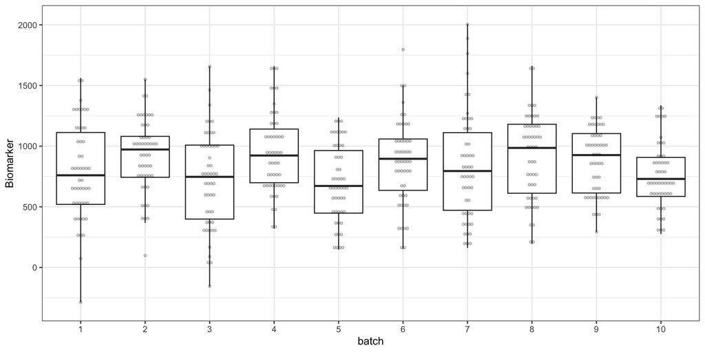

**Note**

Both mean (or “location”) and variance (or “scale”, “spread”) vary by batch.

## Testing for batch effects on the mean

```r
anova(lm(Biomarker ~ batch, data = batch_data)) |>
  broom::tidy() |>
  mutate(p.value = formatp(p.value)) |>
  kable(digits = 3)
```

| term | df | sumsq | meansq | statistic | p.value |
| --- | --- | --- | --- | --- | --- |
| batch | 9 | 3634484 | 403832 | 3.38 | p<0.001 |
| Residuals | 490 | 58539640 | 119469 | NA | NA |

## Testing for batch effects on the variance

```r
# Model 1 (Null): Assumes equal variance across all batches
equal_var <- gls(Biomarker ~ batch, data = batch_data)

# Model 2 (Alternative): Allows different variances for each batch
different_var <- gls(Biomarker ~ batch, data = batch_data,
  weights = varIdent(form = ~1 | batch))

# Perform the Likelihood Ratio Test
anova(equal_var, different_var) |>
  as_tibble(rownames = "model") |>
  mutate(`p-value` = formatp(`p-value`)) |>
  select(-call, -Model) |>
  kable(digits = 3)
```

| model | df | AIC | BIC | logLik | Test | L.Ratio | p-value |
| --- | --- | --- | --- | --- | --- | --- | --- |
| equal_var | 11 | 7180 | 7226 | -3579 |  | NA | NA |
| different_var | 20 | 7173 | 7257 | -3567 | 1 vs 2 | 25 | 0.00295 |

## Fixing batch effects with ComBat

Adjust for batch effects using the ComBat empirical Bayes framework (Johnson, Li, and Rabinovic 2007; Leek et al. 2025), developed for genomics data. This method estimates batch-specific location and scale parameters (as in `gls` fit above) and adjusts the data accordingly.

```r
set.seed(20260603)
batch_data$Biomarker_ComBat <- sva::ComBat(
  dat = rbind(batch_data$Biomarker, jitter(batch_data$Biomarker, factor=1e-9)),
  batch = batch_data$batch,
  par.prior = TRUE,
  prior.plots = FALSE
)[1,]
```

| term | df | sumsq | meansq | statistic | p.value |
| --- | --- | --- | --- | --- | --- |
| batch | 9 | 0 | 0 | 0 | 1.000 |
| Residuals | 490 | 57368847 | 117079 | NA | NA |

| model | df | AIC | BIC | logLik | Test | L.Ratio | p-value |
| --- | --- | --- | --- | --- | --- | --- | --- |
| fit_combat_equal_var | 11 | 7170 | 7216 | -3574 |  | NA | NA |
| fit_combat_diff_var | 20 | 7188 | 7272 | -3574 | 1 vs 2 | 0 | 1.000 |

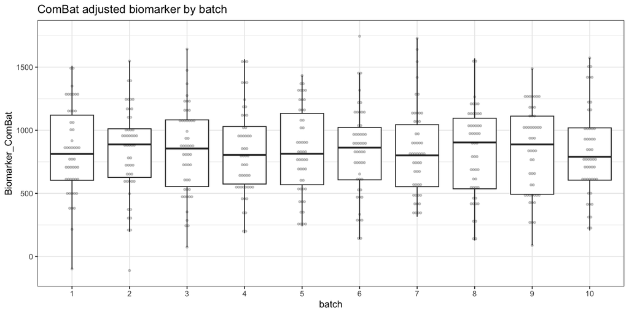

**Note**

- `sva::ComBat` is designed for high throughput data and expects more than 1 marker. Here we create a pseudo marker by duplicating the biomarker with slight “`jitter`”.
- See also `longComBat` for longitudinal data (Beer 2020).

## Practical take-home on batch effects

- randomize samples to plates when possible to avoid confounding batch effects with effects of interest (ComBat cannot fix this)
- visualize by plate or batch before modeling
- use techniques like ComBat to adjust for known technical issues
- do not let biology become confounded with assay logistics

# Baseline characteristics

## Baseline subject characteristics

|  | LEARN (N=538) | Placebo (N=591) | Solanezumab (N=578) | Total (N=1707) | p value |
| --- | --- | --- | --- | --- | --- |
| Age (years) |  |  |  |  | < 0.001 |
| - Mean (SD) | 70.5 (4.3) | 71.9 (5.0) | 71.9 (4.6) | 71.5 (4.7) |  |
| - Range | 65.0 - 85.6 | 65.0 - 85.7 | 65.0 - 85.5 | 65.0 - 85.7 |  |
| Education (years) |  |  |  |  | 0.292 |
| - Mean (SD) | 16.8 (2.6) | 16.5 (2.9) | 16.6 (2.7) | 16.6 (2.8) |  |
| - Range | 8.0 - 30.0 | 8.0 - 30.0 | 7.0 - 30.0 | 7.0 - 30.0 |  |
| Baseline PACC |  |  |  |  | < 0.001 |
| - Mean (SD) | 0.8 (2.3) | 0.0 (2.6) | -0.0 (2.8) | 0.2 (2.6) |  |
| - Range | -8.7 - 6.6 | -12.5 - 7.8 | -10.3 - 6.4 | -12.5 - 7.8 |  |

## Baseline subject characteristics

|  | LEARN (N=538) | Placebo (N=591) | Solanezumab (N=578) | Total (N=1707) | p value |
| --- | --- | --- | --- | --- | --- |
| Baseline amyloid PET (CL) |  |  |  |  | < 0.001 |
| - Mean (SD) | 4.2 (12.6) | 66.0 (32.1) | 66.1 (33.5) | 46.6 (40.2) |  |
| - Range | -32.6 - 35.1 | 0.3 - 205.4 | 0.3 - 201.7 | -32.6 - 205.4 |  |
| APOEε4 carrier |  |  |  |  | < 0.001 |
| - N-Miss | 2 | 0 | 0 | 2 |  |
| - 0 | 413 (77.1%) | 244 (41.3%) | 236 (40.8%) | 893 (52.4%) |  |
| - 1 | 123 (22.9%) | 347 (58.7%) | 342 (59.2%) | 812 (47.6%) |  |
| Baseline pTau217 (U/ml) |  |  |  |  | < 0.001 |
| - N-Miss | 58 | 41 | 46 | 145 |  |
| - Mean (SD) | 0.1 (0.1) | 0.3 (0.1) | 0.3 (0.2) | 0.2 (0.1) |  |
| - Range | 0.1 - 0.7 | 0.1 - 1.3 | 0.1 - 1.5 | 0.1 - 1.5 |  |

## Baseline PACC distribution by treatment

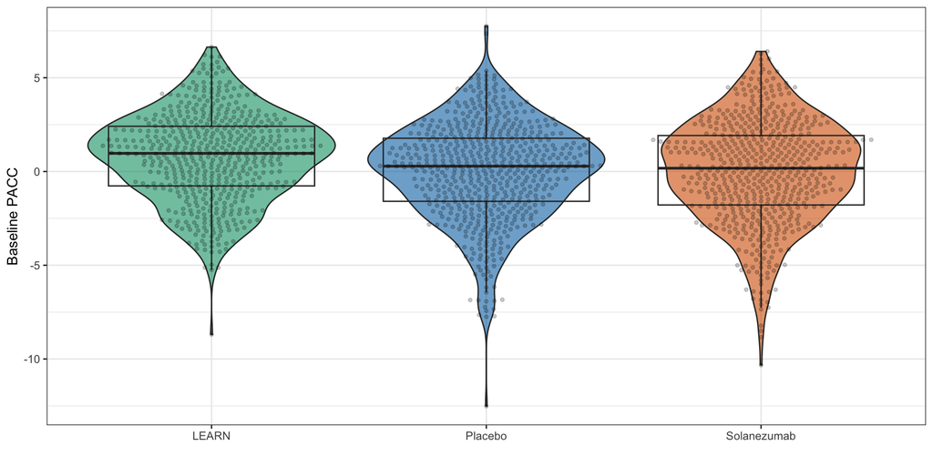

**Note**

- “beeswarm” helps show raw data and reduce overplotting
- “violin plot” shows shape of distribution (“density plot”)
- “box and whiskers plot” shows quartiles, indicates outliers

## Baseline biomarker versus baseline cognition

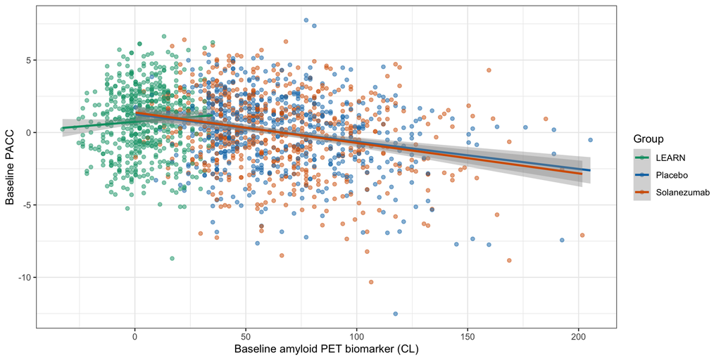

**Note**

- trend lines by group are from “ordinary least squares” linear model
- distinct linear trends in LEARN vs A4
- no hard CL threshold for A4 inclusion due to visual reads

## A simple baseline regression

| term | estimate | std.error | statistic | p.value |
| --- | --- | --- | --- | --- |
| (Intercept) | 0.340 | 0.087 | 3.918 | p<0.001 |
| scale(AMYLCENT) | -0.258 | 0.081 | -3.189 | 0.00146 |
| scale(PTAU217) | -0.270 | 0.076 | -3.558 | p<0.001 |
| scale(AGEYR) | -0.787 | 0.063 | -12.474 | p<0.001 |
| APOE41 | -0.125 | 0.132 | -0.946 | 0.34443 |
| scale(EDUC) | 0.466 | 0.060 | 7.731 | p<0.001 |

Effect of APOE $\epsilon4$ not significant after amyloid PET and p-tau217 adjustment

# Part 2. Imaging biomarker interpretation

# Imaging biomarkers

## The analysis question

> How do we interpret and standardize a baseline imaging biomarker in a way that supports downstream modeling?

## Distribution of baseline amyloid PET (SUVR)

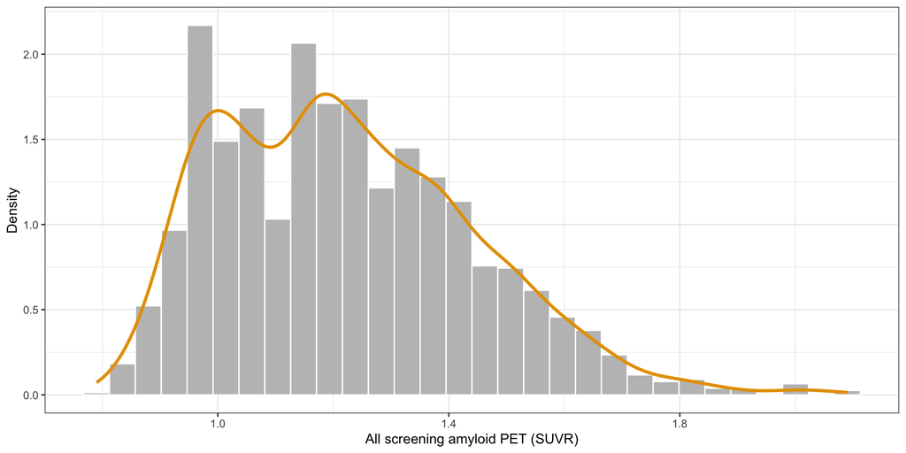

## ECDF standardization

```r
ecdf_suvr <- ecdf(ALL_BASE_PET$SUVRCER)

ALL_BASE_PET <- ALL_BASE_PET |>
  mutate(
    SUVRCER_p = ecdf_suvr(SUVRCER), # 0-1 scale
    SUVRCER_z = qnorm(pmin(pmax(SUVRCER_p, 1e-6), 1 - 1e-6)),
    SUVRCER_pct = SUVRCER_p*100) # 0-100 scale
```

## Percentiles and z-scores

[figure not shown]

## Percentiles and z-scores

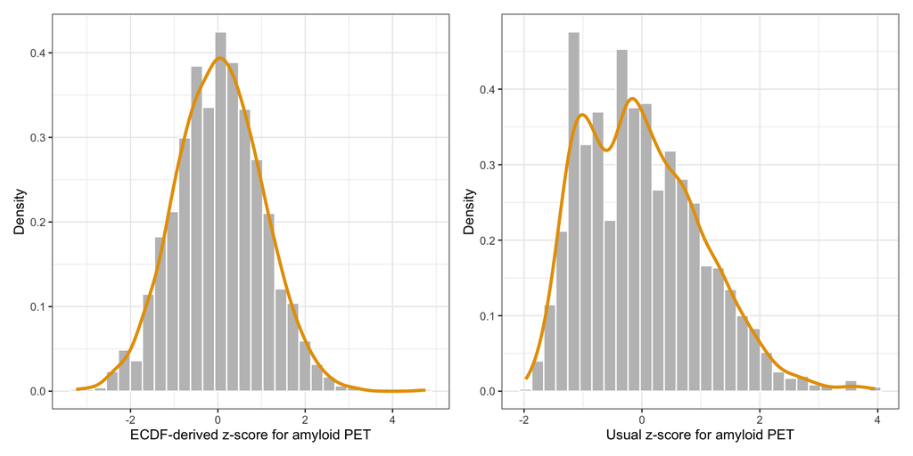

## Percentiles vs Centiloids

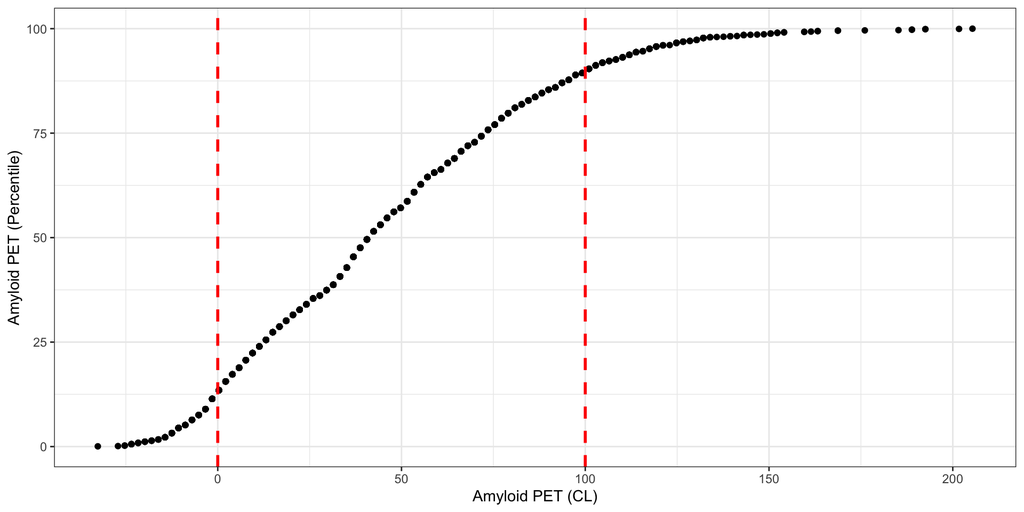

## Why bother with ECDF standardization?

- no parametric assumptions
- percentiles are intuitive
- easy bridge from biomarker scale to standardized scale
- useful for harmonization and modeling
- see also weighted ECDFs for covariate adjustment: [`Hmisc::wtd.Ecdf`](https://search.r-project.org/CRAN/refmans/Hmisc/html/wtd.stats.html)

## Finding unsupervised (latent) threshold with a mixture model

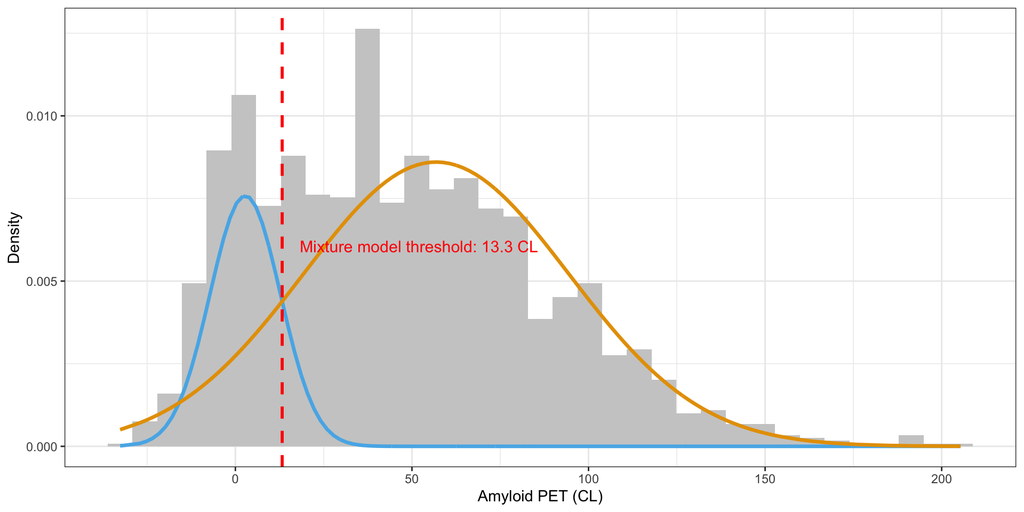

# Part 3. Longitudinal cognition

# Longitudinal PACC

## Start with the plot

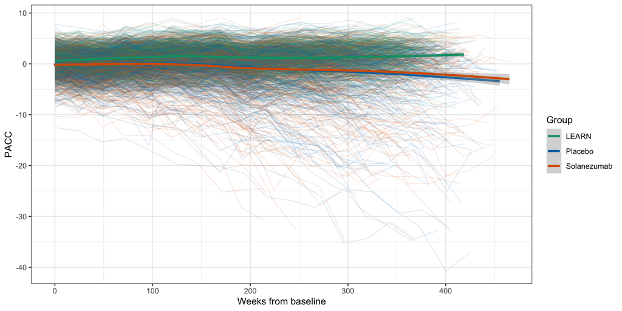

## Longitudinal summaries by treatment and time

| Week | Group | n | sd | mean | lower95 | upper95 |
| --- | --- | --- | --- | --- | --- | --- |
| 0 | LEARN | 538 | 2.35 | 0.79 | 0.59 | 0.99 |
| 0 | Placebo | 591 | 2.6 | 0.01 | -0.2 | 0.22 |
| 0 | Solanezumab | 578 | 2.76 | -0.01 | -0.23 | 0.22 |
| 48 | LEARN | 500 | 2.35 | 0.57 | 0.36 | 0.77 |
| 48 | Placebo | 551 | 2.9 | -0.35 | -0.6 | -0.11 |
| 48 | Solanezumab | 531 | 3.01 | -0.42 | -0.68 | -0.16 |
| 96 | LEARN | 476 | 2.41 | 1.28 | 1.06 | 1.5 |
| 96 | Placebo | 510 | 3.2 | -0.05 | -0.33 | 0.23 |
| 96 | Solanezumab | 498 | 3.51 | -0.19 | -0.5 | 0.12 |
| 144 | LEARN | 440 | 2.51 | 1.36 | 1.13 | 1.6 |

[output cut: 8 more lines]

## Mean profiles with 95% confidence intervals

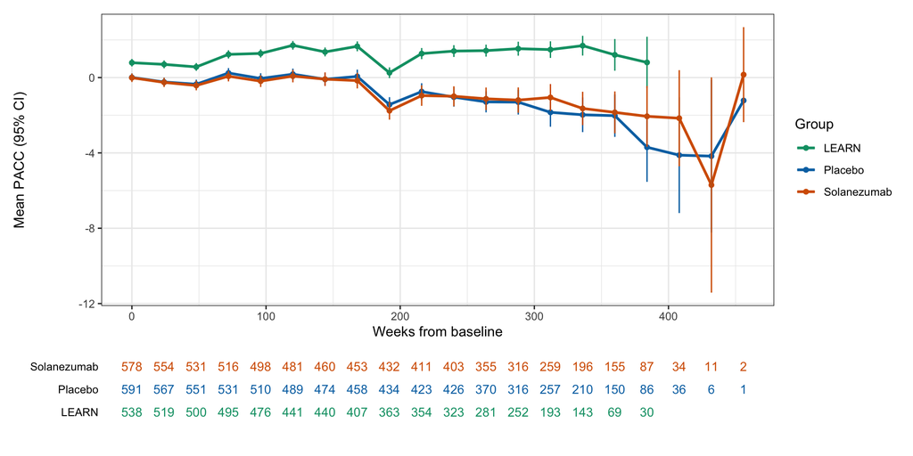

## Why ordinary regression is not enough

- repeated measures within participant are correlated, cannot treat them as independent observations
- complete-case endpoint analyses discard information
- last observation carried forward (LOCF) is biased

## Mixed effects model for PACC

## Fixed effects summary

| term | Value | Std.Error | DF | t-value | p.value |
| --- | --- | --- | --- | --- | --- |
| (Intercept) | 10.927 | 0.904 | 17951 | 12.082 | p<0.001 |
| splines::ns(ADURW, df = 2)1 | 0.556 | 0.364 | 17951 | 1.525 | 0.12718 |
| splines::ns(ADURW, df = 2)2 | -0.855 | 0.324 | 17951 | -2.639 | 0.00833 |
| GroupPlacebo | 0.108 | 0.180 | 1694 | 0.603 | 0.54644 |
| GroupSolanezumab | 0.103 | 0.181 | 1694 | 0.573 | 0.56670 |
| AGEYR | -0.178 | 0.012 | 1694 | -15.110 | p<0.001 |
| APOE41 | -0.110 | 0.117 | 1694 | -0.944 | 0.34517 |
| EDUC | 0.142 | 0.019 | 1694 | 7.338 | p<0.001 |
| AMYLCENT | -0.010 | 0.002 | 1694 | -4.960 | p<0.001 |
| splines::ns(ADURW, df = 2)1:GroupPlacebo | -3.374 | 0.504 | 17951 | -6.696 | p<0.001 |
| splines::ns(ADURW, df = 2)2:GroupPlacebo | -4.579 | 0.443 | 17951 | -10.333 | p<0.001 |
| splines::ns(ADURW, df = 2)1:GroupSolanezumab | -3.813 | 0.507 | 17951 | -7.520 | p<0.001 |
| splines::ns(ADURW, df = 2)2:GroupSolanezumab | -4.603 | 0.446 | 17951 | -10.319 | p<0.001 |

## Random effects summary

```
BID = pdLogChol(ADURW)
            Variance StdDev Corr
(Intercept) 4.142442 2.0353 (Intr)
ADURW       0.000239 0.0154 0.046
Residual    2.053105 1.4329
```

Variance of subject-specific random intercepts and slopes; and variance of the residuals

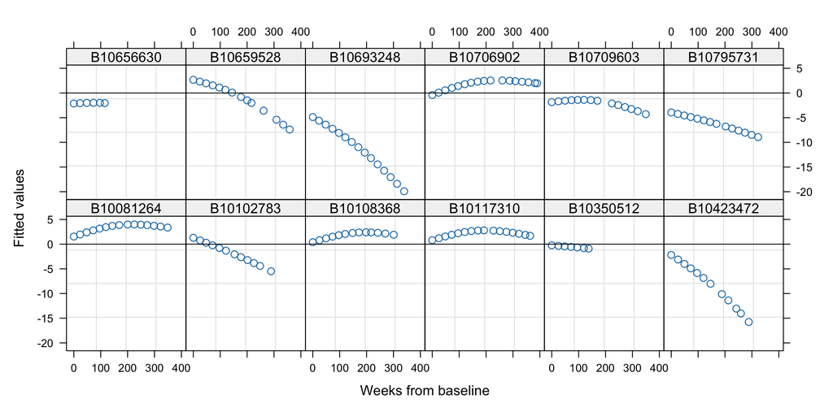

## Interpretation of the model

- fixed effects estimate average relationships in the population
- random intercepts allow different starting levels by participant
- random slopes allow different rates of change by participant
- the `ns(ADURW, df = 2)` terms allows for flexible nonlinear change over time
- the `ns(ADURW, df = 2) × Group` interaction estimates differential longitudinal change by group

## Model-based mean profiles

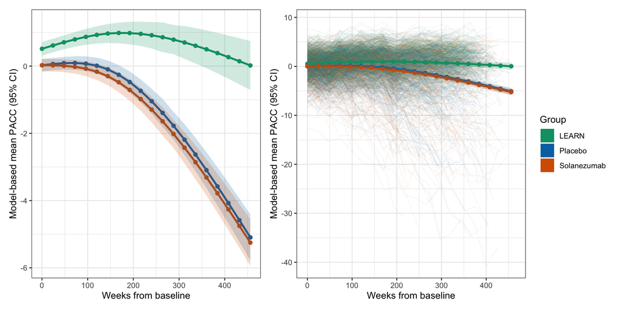

## Latent classes of longitudinal trajectories

Note the downward trend in A4 is driven by a minority of participants with more rapid decline. We have used latent class mixed models to identify subgroups of participants with different longitudinal trajectories (Li et al. 2026). Code [here](https://github.com/atri-biostats/A4LEARN/blob/HEAD/vignettes/articles/A4LEARN-Latent-Classes.qmd).

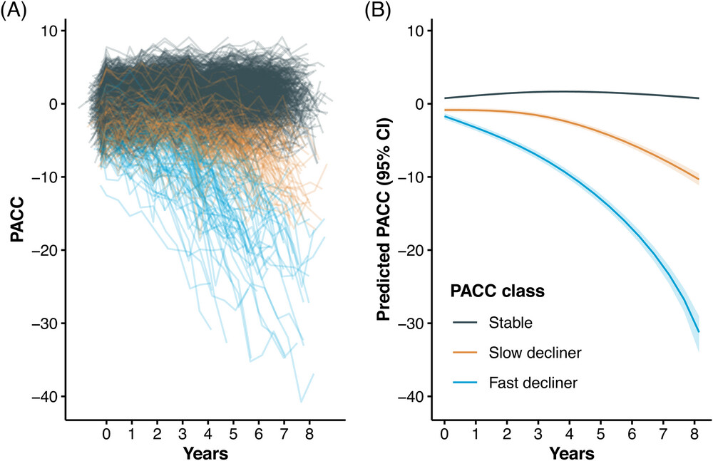

## Do cognitive test version effects matter?

- version effects are a real example of longitudinal nuisance variation
- this is analogous to platform, scanner, or assay-version effects in other settings
- model comparison can help decide whether the nuisance term materially improves fit
- smaller AIC/BIC indicates more parsimonious fit

| Model | AIC | BIC |
| --- | --- | --- |
| With version effect | 78629 | 78779 |
| Without version effect | 79284 | 79418 |

## MMRM versus cLDA, conceptually

Both approaches are used for analysis of **randomized trials with repeated measures**, but they differ in how they handle baseline and time:

### Mixed Model Repeated Measures (MMRM)

- change from baseline as outcome
- baseline as covariate
- time as categorical factor
- residuals usually assumed correlated within participant, but no subject-specific random effects
- very common in randomized trials

### Constrained Longitudinal Data Analysis (cLDA)

- raw scores modeled directly, including baseline
- common baseline mean constraint in randomized groups
- time can be modeled as continuous (e.g. with splines) or categorical (see Donohue et al. (2023))
- often attractive when baseline missingness matters

## Missing data in 2 minutes

- Missing Completely at Random (MCAR) is usually unrealistic
- mixed model likelihood methods using all available observations are generally justified under Missing at Random (MAR): missingness that depends on observed data but not unobserved data
- Missing Not at Random (MNAR) — missingness that depends on *unobserved* data — cannot be ruled out from observed data by definition, but sensitivity analyses can be used to explore the impact of different MNAR assumptions on conclusions

# Synthesis

## A simple decision framework

- **Technical artifact problem**  
  Visualize first, address nuisance (ComBat) or adjust in the model
- **Baseline biomarker and cognition question**  
  Use regression, preserve continuous scales (do not dichotomize if possible)
- **Need for comparability or harmonization**  
  Standardize first, then model
- **Repeated measures outcome**  
  Need longitudinal models that account for within-subject correlation

## If you remember only four things

- visualize before modeling
- adjust technical nuisance before biological interpretation
- standardization choices affect interpretation
- repeated measures require repeated-measures methods

# Backup topics, if time allows

# Spline cLDA with `nlme::gls` with Toeplitz correlation and variance by subject

Mean PACC change from baseline at week 240 by treatment group estimated from spline model.

| TX | estimate | SE | df | t.ratio | p.value |
| --- | --- | --- | --- | --- | --- |
| Placebo | -1.13 | 0.16 | 10791 | -6.87 | p<0.001 |
| Solanezumab | -1.43 | 0.21 | 10791 | -6.94 | p<0.001 |

Mean PACC group change from baseline at week 240 by treatment group estimated from spline model.

| contrast | ADURW | estimate | SE | df | lower.CL | upper.CL | t.ratio | p.value |
| --- | --- | --- | --- | --- | --- | --- | --- | --- |
| Solanezumab - Placebo | 240 | -0.3 | 0.27 | 10791 | -0.82 | 0.22 | -1.13 | 0.259 |

# cLDA using `mmrm::mmrm` with unstructured correlation and variance by subject

Mean PACC change from baseline at week 240 by treatment group estimated from spline model.

| TX | estimate | SE | df | t.ratio | p.value |
| --- | --- | --- | --- | --- | --- |
| Placebo | -1.20 | 0.18 | 1054 | -6.62 | p<0.001 |
| Solanezumab | -1.56 | 0.18 | 1060 | -8.48 | p<0.001 |

Mean group difference in PACC change from baseline at week 240 estimated from spline model.

| contrast | ADURW | estimate | SE | df | lower.CL | upper.CL | t.ratio | p.value |
| --- | --- | --- | --- | --- | --- | --- | --- | --- |
| Solanezumab - Placebo | 240 | -0.36 | 0.26 | 1030 | -0.87 | 0.15 | -1.39 | 0.164 |

# MMRM with `mmrm::mmrm` with categorical time and unstructured correlation

Mean PACC change from baseline at visit 66 by treatment group estimated from categorical time MMRM.

| TX | emmean | SE | df | lower.CL | upper.CL | t.ratio | p.value |
| --- | --- | --- | --- | --- | --- | --- | --- |
| Placebo | -1.64 | 0.25 | 1724 | -2.13 | -1.15 | -6.56 | p<0.001 |
| Solanezumab | -2.02 | 0.25 | 1731 | -2.51 | -1.52 | -7.99 | p<0.001 |

Mean group difference in PACC change from baseline at visit 66 estimated from categorical time MMRM.

| contrast | estimate | SE | df | lower.CL | upper.CL | t.ratio | p.value |
| --- | --- | --- | --- | --- | --- | --- | --- |
| Solanezumab - Placebo | -0.38 | 0.29 | 890 | -0.95 | 0.2 | -1.29 | 0.199 |

# Missing data sensitivity analyses

In the event of a successful treatment effect, multiple imputation of missing values can be used to “stress test” the result and ask:

> How wrong do the values imputed for treated individuals, under the assumption of missing at random, have to be before our conclusion is reversed?

This “delta method” assumes $\delta$% more pessimistic imputed values and reports the smallest $\delta$ such that the p-value is no longer significant.

Mean PACC change from baseline at visit 66 by treatment group estimated from categorical time MMRM.

| TX | emmean | SE | df | lower.CL | upper.CL | t.ratio | p.value |
| --- | --- | --- | --- | --- | --- | --- | --- |
| Placebo | -3.13 | 1.18 | 35.41 | -5.53 | -0.72 | -2.64 | 0.0123 |
| Pseudo | 0.54 | 1.34 | 37.58 | -2.17 | 3.25 | 0.41 | 0.6873 |

Mean group difference in PACC change from baseline at visit 66 estimated from categorical time MMRM.

| contrast | estimate | SE | df | lower.CL | upper.CL | t.ratio | p.value |
| --- | --- | --- | --- | --- | --- | --- | --- |
| Pseudo A - Placebo A | 3.67 | 1.79 | 36.63 | 0.04 | 7.3 | 2.05 | 0.0476 |

# 1. Create multiple complete versions

```r
trial_imp <- mice(trial_wide, m=5, predictorMatrix=pm,
  seed = 20170714, maxit=100, method = meth, print = FALSE)
```

```r
trial_wide[,grepl("PACC_ch|BID", colnames(pm))] |>
  filter(BID %in% c("B10350512", "B10656630", "B10892860"))
```

```
# A tibble: 3 × 11
  BID    PACC_ch_012 PACC_ch_018 PACC_ch_024 PACC_ch_030 PACC_ch_036 PACC_ch_042
  <chr>        <dbl>       <dbl>       <dbl>       <dbl>       <dbl>       <dbl>
1 B1035…       0.867      -0.439      0.0434        2.68        2.25        2.49
2 B1065…      -1.36       -1.03      -1.65         -2.68       -1.76       NA
3 B1089…      -5.70       NA         NA            NA          NA          NA
# ℹ 4 more variables: PACC_ch_048 <dbl>, PACC_ch_054 <dbl>, PACC_ch_060 <dbl>,
#   PACC_ch_066 <dbl>
```

```r
complete(trial_imp)[,grepl("PACC_ch|BID", colnames(pm))] |>
  filter(BID %in% c("B10350512", "B10656630", "B10892860"))
```

```
        BID PACC_ch_012 PACC_ch_018 PACC_ch_024 PACC_ch_030 PACC_ch_036
1 B10350512       0.867      -0.439      0.0434        2.68        2.25
2 B10656630      -1.361      -1.033     -1.6458       -2.68       -1.76
3 B10892860      -5.702      -1.892      0.5952       -5.86        1.11
  PACC_ch_042 PACC_ch_048 PACC_ch_054 PACC_ch_060 PACC_ch_066
1       2.487       2.159      -0.887        3.81        3.95
2      -3.279       0.928      -1.876        2.86        4.09
3       0.623       0.249      -1.960      -12.97       -4.87
```

Multiple Imputation by Chained Equations (MICE) (S. van Buuren and Groothuis-Oudshoorn 2010; S. van Buuren 2018)

# 2. Analyze each of 5 complete datasets

```
# A tibble: 40 × 7
   term                  estimate std.error statistic  p.value  nobs df.residual
   <chr>                    <dbl>     <dbl>     <dbl>    <dbl> <int>       <dbl>
 1 (Intercept)             2.55     11.5       0.222   8.25e-1    50          42
 2 active                  5.27      1.30      4.07    2.06e-4    50          42
 3 scale(PACC_bl)          1.55      0.871     1.78    8.31e-2    50          42
 4 AGEYR                  -0.0128    0.135    -0.0942  9.25e-1    50          42
 5 APOE41                  0.509     1.33      0.382   7.05e-1    50          42
 6 EDUC                    0.0920    0.317     0.290   7.73e-1    50          42
 7 AMYLCENT               -0.0928    0.0213   -4.36    8.29e-5    50          42
 8 active:scale(PACC_bl)  -3.81      1.37     -2.79    7.88e-3    50          42
 9 (Intercept)            22.8      11.4       1.99    5.29e-2    50          42
10 active                  3.61      1.29      2.79    7.92e-3    50          42
# ℹ 30 more rows
```

# 3. Combine the 5 results

|  | estimate | std.error | statistic | df | p.value |
| --- | --- | --- | --- | --- | --- |
| (Intercept) | 13.027 | 14.284 | 0.912 | 15.62 | 0.37563 |
| active | 4.405 | 1.507 | 2.923 | 22.10 | 0.00785 |
| scale(PACC_bl) | 1.978 | 1.230 | 1.608 | 9.56 | 0.14022 |
| AGEYR | -0.083 | 0.162 | -0.509 | 18.98 | 0.61639 |
| APOE41 | 0.371 | 1.527 | 0.243 | 23.91 | 0.81000 |
| EDUC | -0.224 | 0.567 | -0.394 | 5.26 | 0.70881 |
| AMYLCENT | -0.090 | 0.027 | -3.277 | 13.53 | 0.00572 |
| active:scale(PACC_bl) | -5.502 | 2.312 | -2.380 | 5.91 | 0.05541 |

# “Tipping point” MNAR stress test

Treatment effects for different MNAR factors:

| tipping_factor | delta | term | estimate | std.error | statistic | df | p.value |
| --- | --- | --- | --- | --- | --- | --- | --- |
| 0.0 | 0.00 | active | 4.41 | 1.51 | 2.92 | 22.1 | 0.00785 |
| 0.5 | 2.20 | active | 3.52 | 1.52 | 2.32 | 22.4 | 0.02991 |
| 0.6 | 2.64 | active | 3.34 | 1.52 | 2.19 | 22.5 | 0.03888 |
| 0.7 | 3.08 | active | 3.17 | 1.53 | 2.07 | 22.7 | 0.05031 |
| 0.8 | 3.52 | active | 2.99 | 1.54 | 1.94 | 22.8 | 0.06472 |
| 0.9 | 3.96 | active | 2.81 | 1.55 | 1.81 | 23.1 | 0.08269 |
| 1.0 | 4.41 | active | 2.63 | 1.56 | 1.69 | 23.3 | 0.10479 |

Imputed PACC_ch_066 values are only changed for those in active group

# References

ATRI Biostatistics. 2025. *A4LEARN: A4LEARN Study Package*. https://www.a4studydata.org.

Beer, Joanne. 2020. *longCombat: Longitudinal ComBat for Harmonizing Multi-Batch Longitudinal Data*. https://github.com/jcbeer/longCombat.

Buuren, S van, and Karin Groothuis-Oudshoorn. 2010. “Mice: Multivariate Imputation by Chained Equations in r.” *Journal of Statistical Software*, 1–68.

Buuren, Stef van. 2018. *Flexible Imputation of Missing Data*. 2nd ed. Boca Raton, FL: Chapman; Hall/CRC. https://doi.org/10.1201/9780429492259.

Donohue, Michael C, Kedir Hussen, Oliver Langford, Richard Gallardo, Gustavo Jimenez-Maggiora, Paul S Aisen, and Alzheimer’s Disease Neuroimaging Initiative. 2026. “Alzheimer’s clinical research data via R packages: The alzverse.” *Alzheimer’s & Dementia* 22 (2): e71152.

Donohue, Michael C, Oliver Langford, Philip S Insel, Christopher H van Dyck, Ronald C Petersen, Suzanne Craft, Gopalan Sethuraman, Rema Raman, Paul S Aisen, and Alzheimer’s Disease Neuroimaging Initiative. 2023. “Natural Cubic Splines for the Analysis of Alzheimer’s Clinical Trials.” *Pharmaceutical Statistics*. https://doi.org/10.1002/pst.2285.

Johnson, W Evan, Cheng Li, and Ariel Rabinovic. 2007. “Adjusting Batch Effects in Microarray Expression Data Using Empirical Bayes Methods.” *Biostatistics* 8 (1): 118–27.

Leek, Jeffrey T., W. Evan Johnson, Hilary S. Parker, Elana J. Fertig, Andrew E. Jaffe, Yuqing Zhang, John D. Storey, and Leonardo Collado Torres. 2025. *sva: Surrogate Variable Analysis*. https://doi.org/10.18129/B9.bioc.sva.

Li, Runpeng, Oliver Langford, Philip S Insel, Reisa A Sperling, Rema Raman, Paul S Aisen, and Michael C Donohue. 2026. “Divergent patterns of cognitive decline in preclinical Alzheimer’s disease: Implications for secondary prevention trials.” *Alzheimer’s & Dementia* 22 (4): e71366. https://doi.org/10.1002/alz.71366.

Sperling, Reisa A, MC Donohue, RA Rissman, KA Johnson, DM Rentz, JD Grill, JL Heidebrink, et al. 2024. “Amyloid and tau prediction of cognitive and functional decline in unimpaired older individuals: longitudinal data from the A4 and LEARN studies.” *The Journal of Prevention of Alzheimer’s Disease* 11 (4): 802–13.

Sperling, Reisa A, Michael C Donohue, Rema Raman, Michael S Rafii, Keith Johnson, Colin L Masters, Christopher H van Dyck, et al. 2023. “Trial of solanezumab in preclinical Alzheimer’s disease.” *New England Journal of Medicine* 389 (12): 1096–1107.